# pfase1

### TTotalTren

#### Tren recorre una estacion

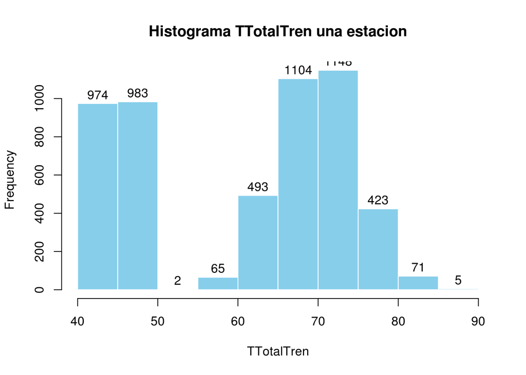

#### Resumen

```
##    Min. 1st Qu.  Median    Mean 3rd Qu.    Max.
##    40.0    46.8    65.7    60.7    71.3    88.3
```

#### Varianza

```
## [1] 163.2
```

#### Tren recorre dos estaciones

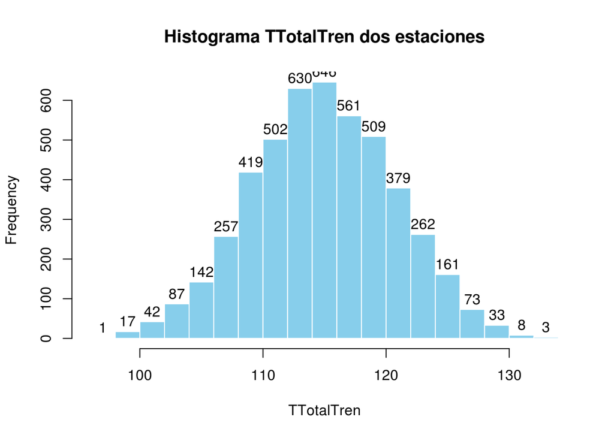

#### Resumen

```
##    Min. 1st Qu.  Median    Mean 3rd Qu.    Max.
##    96.8   111.0   115.0   115.0   119.0   133.0
```

#### Varianza

```
## [1] 33.13
```

#### Variable Aleatoria: Exponencial

- Dado que lo usuarios solo recorren como maximo 2 estaciones, tomamos la media de los intervalos de tiempo que el tren tarda en recorrer una y dos estaciones. Con esto, podemos medir el tiempo que tarda un tres en llegar a una estacion X dado que recorrio una o dos estaciones y asi asociar la variable aleatoria con una distribucion exponencial. Tendremos dos variables aleatorias asociadas a esta distribucion:

##### Nombre:

- “Tiempo que tarda un tren en llegar a una estacion dado que recorrio una estacione”

##### Parametros:

- lambda = 60.7

##### Nombre:

- “Tiempo que tarda un tren en llegar a una estacion dado que recorrio dos estaciones”

##### Parametros:

- lambda = 115